# Fundamentals of Creating R Package

Riaz Khan, MS, Statistics, SDSU

02/02/2020

# System preparation

- Install the latest version of R and RStudio:
  - R (3.6.2): https://cran.r-project.org/
  - RStudio (1.2.5033): https://rstudio.com/products/rstudio/download/#download
- Install the following packages:
  - `devtools`
  - `roxygen2`
  - `testthat`
  - `knitr`

```r
install.packages("devtools")
install.packages("roxygen2")
install.packages("testthat")
install.packages("knitr")
```

- Check if the system is ready for package building:

```r
devtools::has_devel()
```

If following message is shown, it suggests that the system is ready for package development. The C compiler installation part can be skipped.

`Your system is ready to build packages!`

Depending on the system, a C compiler may or may not be required. If required:

- For windows, install Rtools https://cran.r-project.org/bin/windows/Rtools/
- For Mac, get Xcode (available for free in the App Store)

> Optional: Get the updated version of `devtools` from GitHub by running `devtools::install_github("r-lib/devtools", force = TRUE)`

# Create library

To create a new package, open RStudio

- `File >> New Project >> New Directory >> R Package`

Give the name of the package `straightline`

[figure not shown]

## Package naming guidelines

- Unique name
- Matcehs with the type of problem the library deals with
  - Easy to google
  - Example `neuralnet`, `NLP`
- Case consistency
  - Same case preferred
  - Mixing not uncommom (`randomForest`)
- It is not uncommon to see an extra r in the name
  - Example: `stringr`, `knitr`
  - `straightliner`? Instead of `straightline`
- Formal requirements for an R package:
  - Contains only alphabetic letter, number and period
  - Cannot end with a period
  - Can start with only letter

# Package configuration

To let roxygen to some heavylifting, go to `Buid > Configure Build Tools` and configure as follows:

[figure not shown]

# Build and check package

RStudio includes a `hello` function with documentation in a default package when a package is created. To build the package, `Build > Install and Restart` (`Cntl + Shift + B`). This will install the package in the system and will be included in R session.

After building, check the package, `Build > Check Package` (`Cntl + Shift + E`). This command will check the package using best practices.

If everything left unaltered, the check should return with a warning for non-standard license.

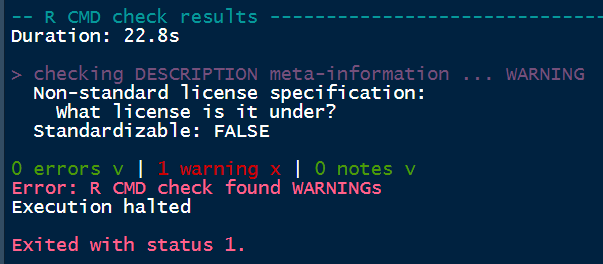

# Package metadata

- Every package must have a description
- There will be an auto-generated `DESCRIPTION` file
- Using the file explorer-plot window of RStudio, go to the package folder and double click the `DESCRIPTION` file. This will open the file in RStudio editor window.

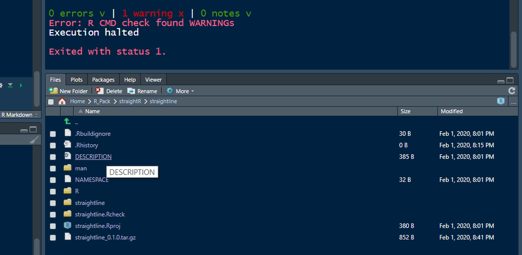

Edit `Title`, `Version`, `Author`, `Maintainer`, `Description` and `License` in the `DESCRIPTION` file. An example:

```r
Package: straightline
Type: Package
Title: An Example R Package for Straight Line in 2d Coordinate System
Version: 1.1.1
Author: Riaz Khan
Maintainer: Riaz Khan <rk@sdsu.net>
Description: This package will do basic calculations of a straight
    line in 2D coordinate system. This package will do basic
    calculations of a straight line in 2D coordinate system. This
    package will do basic calculations of a straight line in 2D
    coordinate system.
License: GPL-3
Encoding: UTF-8
LazyData: true
RoxygenNote: 7.0.2
```

## Version

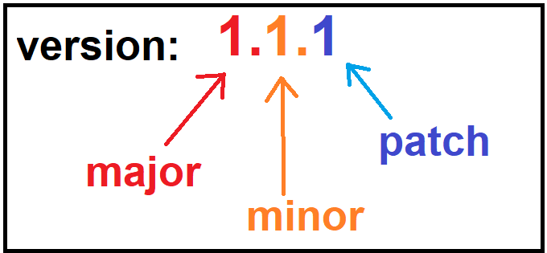

## Multiple authors

If there are multiple authors/contributors, then `Authors@R` field can be used:

```r
Package: straightline
Type: Package
Title: An Example R Package for Straight Line in 2d Coordinate System
Version: 1.1.1
Authors@R: c(person("Riaz", "Khan",
            email = "rk@sdsu.net",
            role = c("aut", "cre")),
            person("Second", "Author",
            email = "se@sdsu.net",
            role = "aut" ))
Description: This package will do basic calculations of a straight
    line in 2D coordinate system. This package will do basic
    calculations of a straight line in 2D coordinate system. This
    package will do basic calculations of a straight line in 2D
    coordinate system.
License: GPL-3
Encoding: UTF-8
LazyData: true
RoxygenNote: 7.0.2
```

Following roles can be added in the `Authors@R` filed:

- `cre`: maintainer
- `aut`: author having significant contributions
- `ctb`: contributors with smaller contributions
- `cph`: copyright holder, in case where the copyright holder is other than the author (e.g employer of the author)

## License

There are three that can be used in an R package:

- `MIT`: Simple permissive. Anyone can do anything as long as the original copyright and licence notice included. See https://tldrlegal.com/license/mit-license
- `GPL-2`, `GPL-3`: If the code is distributed in a bundle, then the whole bundle must be in GPL license. In case of code modification, the source code must be available. GPL-3 is little stricter than GPL-2. See https://tldrlegal.com/license/gnu-general-public-license-v2, https://tldrlegal.com/license/gnu-general-public-license-v3-(gpl-3)

## Dependencies

Frequently, a new package uses the functionality of other packages. For this package dependency, `Imports` field must be used. If a package is used, but not required (likely for examples), then those should be declared as `Suggests`. For example:

```r
Package: straightline
Type: Package
Title: An Example R Package for Straight Line in 2d Coordinate System
Version: 1.1.1
Authors@R: c(person("Riaz", "Khan",
            email = "rk@sdsu.net",
            role = c("aut", "cre")),
            person("Second", "Author",
            email = "se@sdsu.net",
            role = "aut" ))
Description: This package will do basic calculations of a straight
    line in 2D coordinate system. This package will do basic
    calculations of a straight line in 2D coordinate system. This
    package will do basic calculations of a straight line in 2D
    coordinate system.
Imports: ggplot2
Suggests: MASS
License: GPL-3
Encoding: UTF-8
LazyData: true
RoxygenNote: 7.0.2
```

## Package documentation

So far, we have only one function in our package, called `hello`. Let us see the documentation of this function.

```r
?hello
```

A description, usage and example is given in the function `Help` section. This documentation is creted by the default `Rd` file. Go to `~/man/hello.Rd` to see the actual codes that generated this documentation.

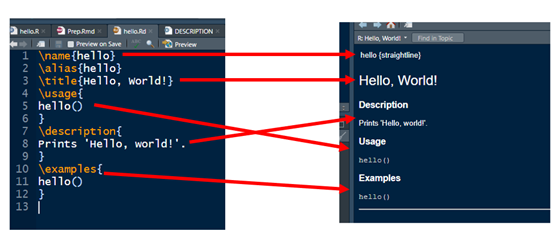

**Note**:

- Documentation and R files live in separate folders
  - `~/man` and `~/R` folders respectively
- `R` and `Rd` documents need to be written separately
- Roxygen– codes and documentation simultaneously
- `Roxygen` auto generates the `Rd` files
  - When we configured at the beginning, we told roxygen to handle the `Rd` files along with other things

Go to the manual directory and delete the `hello.Rd` file. Then build the package (`ctrl+Shift+B`) and run the following again.

```r
?hello
```

Now there is no documentation for the `hello` function. Now we will try to re-create the documentation.

- Go to the `hello.R`, put the cursor on `hello` where the function is defined. Then click `Code > Insert Roxygen Skeleton`. This will create some `roxygen` style field for function documentation. These fields can be used for function documentation.

**Note**: The title can be documented using the `@title` tag.

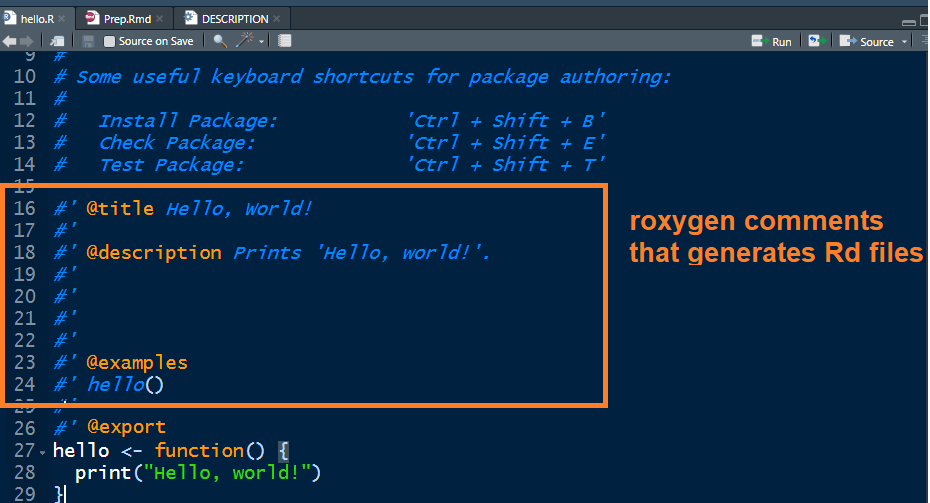

Now, build the package again. Examine the `Rd` file that is genrated by `roxygen`. Now, documentation will be available for the `hello` function.

**Note**: It is recommended that we check the package periodically (`ctrl+Shift+E`). If checking gives warning that the NAMESPACE will not be overwritten, then delete the NAMESPACE and build+check again. `Roxygen` generates the NAMESPACE and the `Rd` files each time we build package.

# Writing own function

Functions are main drivers of specific tasks that the package is intended for. Now we will make our own function and document it.

We will write a function (let us call it `straighten`) that takes three inputs $a$, $b$, and $c$, which are the parameters of a straight line of form $ax+by+c=0$ in 2D coordinate system. The function will throw error message if $a$ and $b$ both are zero. We want the function to return the followings:

- the value of `a`
- the value of `b`
- the value of `c`
- the slope of the straight line
- x intercept of the straight line
- y intercept of the straight line
- the angle between x axis and the straight line in degrees

Additionally, we want the `return object` of the function of its own class, `stline`

## straight line 101

In 2D coordinate system, if a straight line has the form of $ax+by+c=0$, then:

- $slope=-a/b$
- $x\ intercept = -c/a$
- $y\ intercept = -c/b$
- $angle\ with\ x\ axis=tan^{-1}(slope)$
- line parallel to $x$ axis, if $a=0$
- line parallel to $y$ axis, if $b=0$
- passes through the origin, if $c=0$

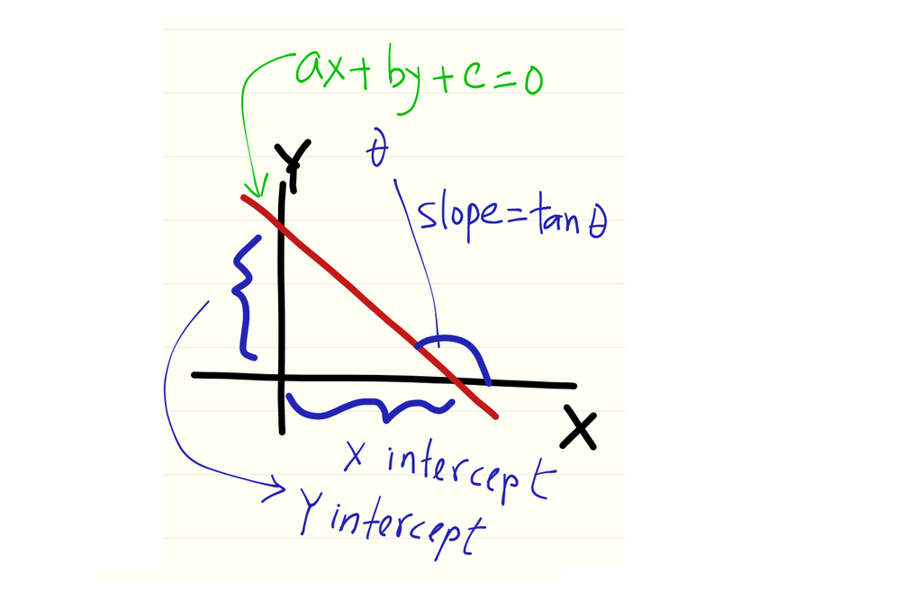

## Function `straighten`

- Function in `~/R` folder
- file: `straighten.R`

```r
straighten <- function(a, b, c){
  if(a==0 & b==0){
    # error message
    stop("a and b both cannot be zero")
  }
  # calculations
  slope <- - a / b
  x_intercept <- - c / a
  y_intercept <- - c / b
  angle_x <- atan(slope) * (180 / pi)
  # outputs in a list
  value <- as.list(c(a = a, b = b, c = c,
             slope = slope,
             x_intercept = x_intercept,
             y_intercept = y_intercept,
             angle_x = angle_x))
  # output class
  class(value) <- "stline"
  # return output
  return(value)
}
```

Please add `roxygen` comments to document the function.

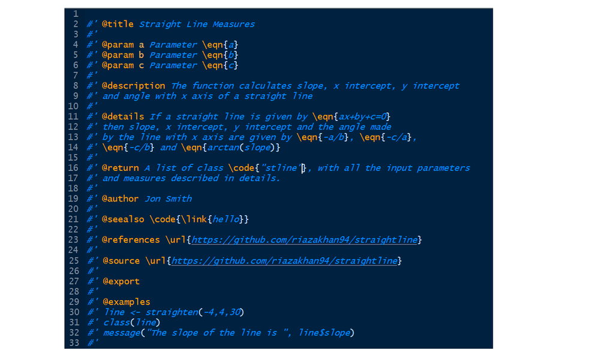

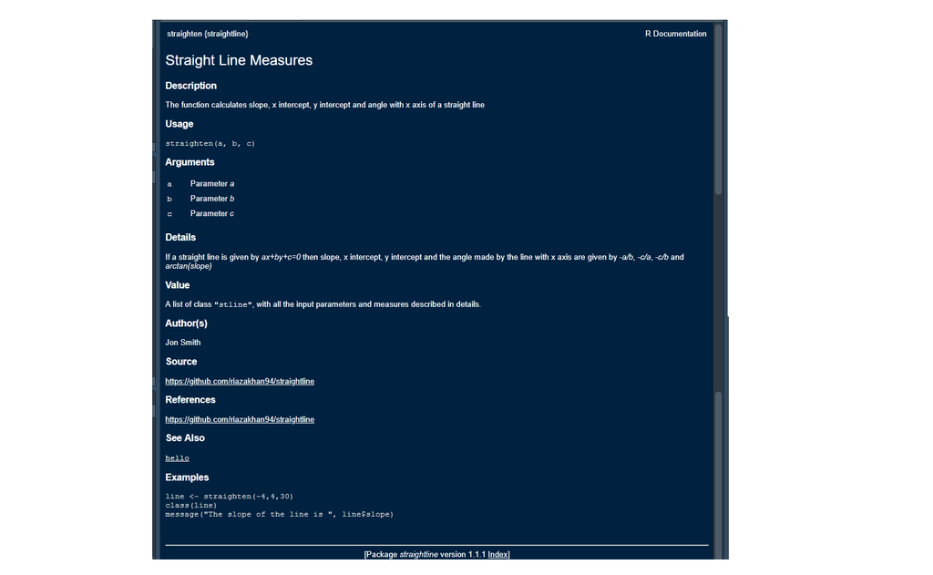

## Coding style: best practices

- Lower case recommended for function and object, with efficient use of underscore (`_`)
- There should be spaces before and after all infix operators (e.g: `+`, `-`, `*`, `/`, `=`, `==`, `<-`, `->`)
  - Space after comma, not before
- Use of `<-` for assignment (not `=`)
- Spelling out `TRUE` and `FALSE`, as opposed to just using `T` and `F`
- Opening curly brace followed by a new line
- Closing curly brace gets its own line
  - Exception: use of `else`
- Limited number of characters per line
- Use of unique name to avoid conflicts
- Proper indentations for easy understanding

> For indentation, select the code block, then `Code > Reindent Lines`

# S3 method: `print` for class `stline`

It is recommended that `print` method can be applied to an object of user defined class. Here we will define the `print` function applicable for `stline` object.

```r
#'
#' @title Print \code{"stline"} Object
#'
#' @param object An object of class \code{"stline"}
#'
#' @param ... NULL; supplied for S3 method consistency
#'
#' @examples
#' line <- straighten(1, 0, 5)
#' print(line)
#'
#' line2 <- straighten(7, -5, 0)
#' print(line2)
#'
#' @method print stline
#'
#' @export
print.stline <- function(x, ... = NULL){
  char_a <- paste0("(", as.character(round(x$a, 3)), ")", "*x")
  char_b <- paste0("(", as.character(round(x$b, 3)), ")", "*y")
  char_c <- paste0("(", as.character(round(x$c, 3)), ")")
  Equation <- paste(char_a, "+", char_b, "+", char_c)
  message("Straight Line Equation      : ", Equation)
  message("Slope                       : ", x$slope)
  message("x intercept                 : ", x$x_intercept)
  message("y intercept                 : ", x$y_intercept)
  message("Angle with x axis (degrees) : ", x$angle_x)
  if(x$a == 0){
    message("Line parallel to x axis")
  }
  if(x$b == 0){
    message("Line parallel to y axis")
  }
  if(x$c == 0){
    message("Line passes through origin")
  }
}
```